# Statistics from Bus Passengers

My analysis explored patterns in bus passenger experiences by examining three key variables: number of passengers, timing of the bus (early or delayed), and the rider’s rating of the experience. From this I discovered interesting correlations. I used my data from project 2 to complete this study.

## Average Bus Ride Rating per Number of Passengers

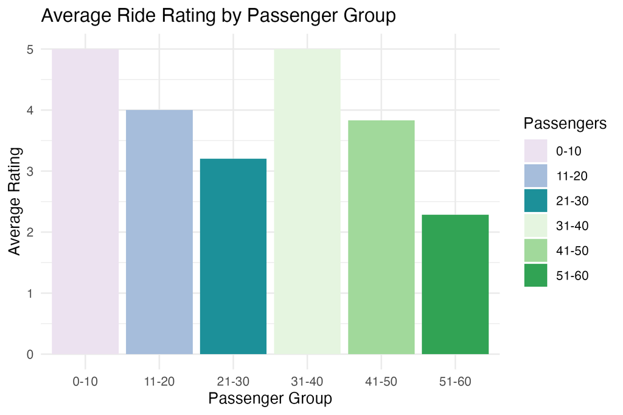

## Average Bus Delay by Hour of the Day

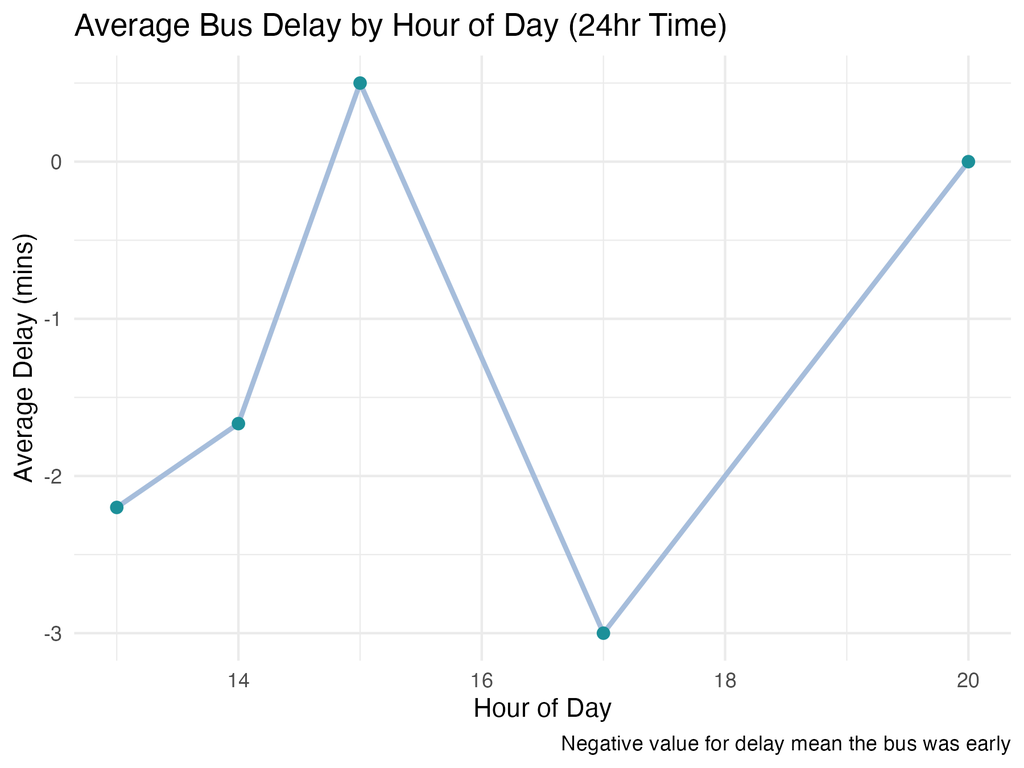

Plot2

This line graph shows the relationship between delay/ early arrival of the bus in relation to the time of day it came. The max average delay of 0.5 mins tended to happen around 3pm where as the bus was earliest by 3 mins around 5pm. An interesting take away from creating this plot is how majority of the averages fall in the negatives, note only 1 point is positive. This means that on average the bus is early except around 3pm.